# T-Grains Starter Stakeholders

Dr Elliot Meador

10/05/2019

# 1 Starter stakeholders

## 1.1 Overview

The majority of the starter-stakeholders are CSA’s though not all. There are several major *broker* users in the network. These are users who help promote and advocate for small-holder argriculture and sustainable/organic food systems. An example of one broker in the starter-stakeholders group is the CSANetwork.

## 1.2 Starter-Stakeholders

The table below details the general structure of the data after a bit of processing is done. We first pull the user’s screen name and their tweets. Then, we pull all the mentioned users from the tweet (names that start with the ‘@’ symbol). We then create one row for each distinct screen name, tweet and mentioned screen name. This forms a natural edgelist that is used to make the network graphs. The tweets, which connect the screen names and the mentioned screen names, can be analysed using text mining (natural language process, sentiment analysis, etc.)

Random Sample of 5 starter-stakeholders and their first-degree tie

| screen_name | text | mentions_screen_name |
| --- | --- | --- |
| turriefield | @1999Smallhold Kale pesto? | 1999Smallhold |
| SuttonFarm | @SJB2010 @hackbridgestink @TalkERF_SLondon @XRSutton @XRCroydon @SuttonCouncil In general, bigger is better! (e.g 5 litres) Could you please send a picture for our growing team? Thanks! | TalkERF_SLondon |
| FoodSmilesStA | Filling the car with lovely plants from @CarpentersNurs (and some others) - please come down to #IncredibleEdible Russell Avenue tomorrow (Saturday) 10am-1pm and help us plant them out! https://t.co/v… | CarpentersNurs |
| FCFCGWales | This is fantastic news, congratulations to @ClynfywF for their nomination for not one but TWO Rural Business Awards for Wales and NI! https://t.co/FaYpQdwJ5D #CareFarming #SocialFarming https://t.co/I… | ClynfywF |
| LoveYourVeg | OrganicLea has always had a volunteer programme at its heart, and a specific commitment to volunteers, students and trainees in health-recovery. To support this work further we are recruiting for a He… | organiclea |

## 1.3 Tweets over time

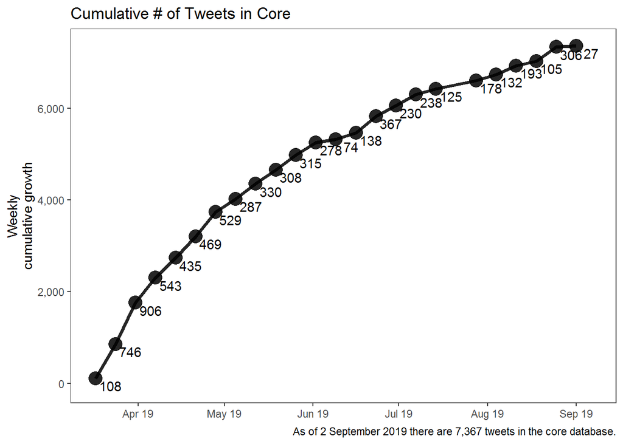

We have collected 7,367 tweets from starting stakeholders.

On average, starter-stakeholders tweet about 9.47 times per week. Though some tweet, on average, as many as 43 and some as low as 1. The figure below shows the number of tweets per week for each starting-stakeholder. The figure is interactive, and a guide is shown in the upper right-hand corner.

[interactive chart not shown]

## 1.4 Starter-stakeholder geography

Most of the starker-stakeholders are located in England, with about 62.1%. Scotland is second with about 20.7%. There are three in Wales and one in Northern Ireland. Some locations are shown in the map below.

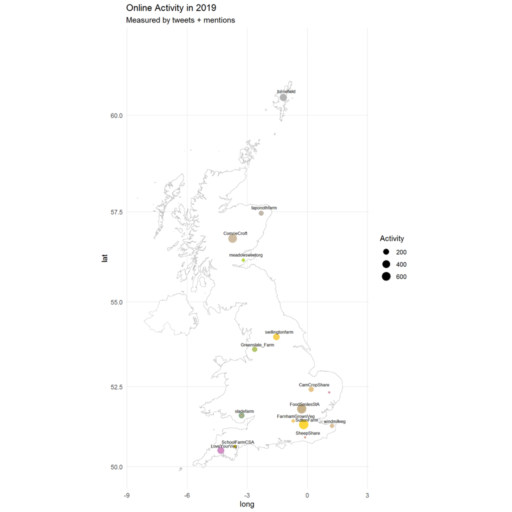